# Dumbbell lifts classification

Maxime Jeanmart

Saturday, March 21, 2015

# Executive summary

In this document, we’ll use machine learning techniques to predict the quality of weight lifting exercise. In the original research, six young health participants were asked to perform one set of 10 repetitions of the Unilateral Dumbbell Biceps Curl in five different fashions: one correct and 4 incorrect. The data set we’re working with contains the measures from the different sensors placed on the subject, along with a class reprensenting the fashion the exercise was performed.

As we’ll see we could create a prediction model showing 99% accuracy using a random forest algorithm. This was later confirmed by applying the model with success on 20 samples whose outcome class was unknown.

# Introduction

We’ll be analysing a data set produced in the context of a human activity recognition research (see [2]). The goal was to be able to differentiate correct from incorrect movements during physical activities. In this specific data set, 6 people were asked to lift a dumbbell 10 times in 5 different fashions. Those fashions are reprensented in the data set by letters in the *classe* column (see [1], chapter 5).

- *A*: exactly according to the specification
- *B*: throwing the elbows to the front
- *C*: lifting the dumbbell only halfway
- *D*: lowering the dumbbell only halfway
- *E*: throwing the hips to the front

The research team recorded the subject movements using four 9 degrees of freedom Razor inertial measurement units (IMU), which provide three-axes acceleration, gyroscope and magnetometer data (see [1], chapter 5). We will try to use machine learning algorithms on this data in order to predict the class of the movements with enough accuracy. We have 2 data sets at our disposal. A first one contains 19622 observations of 160 variables and contains the class of the movement. We’ll be using this data set for training and testing the machine learning model. Another data set contains 20 observations and doesn’t contain the class. This one will be used as validation set. We can verify that we predicted the correct class by sumitting the result on Coursera web site ([3]).

# Data cleaning and feature selection

The first step is to make the data set tidy. There are some variables in the data set that should not affect the model, such as the user name or the time stamps. From the original paper [1], we see that features were extracted using a sliding window approach ([2], section 5.1). For each step, the following features were calculated: Euler angles (roll, pitch and yaw), raw accelerometer, gyroscope and magnetometer readings. Height statistics were calculated for each Euler angle of the 4 sensors. In the data set, the statistics are available in the rows where $new\_window = yes$. This suggests that those rows contains summary of the other rows in the same time window. In the original paper, they only used those rows for prediction (they used feature selection algorithms and kept some statistics as result). However, I’ve decided to train the model on raw data instead, thus reducing the number of features to analyze.

So I’ll remove from the data set the summary rowsn where $new\_window = yes$, and the statistics columns, which are therefore not relevant anymore. Finally, I will remove some meta data columns, such as $X$ (row index), $user\_name$, time stamps and window columns.

```r
library(lattice);library(ggplot2);library(caret);
set.seed(159753)  # enable reproducibility

# there are a lot of blank data, 'NA' and '#DIV/0!' fields that we need to consider as NA values
data <- read.csv("pml-training.csv", na.strings=c('', 'NA', '#DIV/0!', ' '), stringsAsFactors=FALSE)

# the outcome must stay a factor for random forest
data[,'classe'] <- as.factor(data[,'classe'])

# remove summary & stat rows
data <- data[data$new_window=='no',]

# remove index (X), user_name, time stamps and window columns
data <- data[, setdiff(names(data), c('X', 'user_name', 'raw_timestamp_part_1', 'raw_timestamp_part_2', 'cvtd_timestamp', 'new_window', 'num_window'))]

#remove the 8 statistics columns
toRemove <- grepl("^kurtosis\\_", names(data)) |
    grepl("^skewness\\_", names(data)) |
    grepl("^max\\_", names(data)) |
    grepl("^min\\_", names(data)) |
    grepl("^amplitude\\_", names(data)) |
    grepl("^var\\_", names(data)) |
    grepl("^avg\\_", names(data)) |
    grepl("^stddev\\_", names(data))
data <- data[, !toRemove]
```

After those steps, I’ve also tried removing columns with little variance using *nearZeroVar* function. However, no more column could be removed from the data set in that way.

```r
nearZeroVar(data, saveMetrics=TRUE)
```

```
##                      freqRatio percentUnique zeroVar   nzv
## roll_belt             1.086168    6.83805162   FALSE FALSE
## pitch_belt            1.036649    9.53892590   FALSE FALSE
## yaw_belt              1.047244   10.10616153   FALSE FALSE
## total_accel_belt      1.069434    0.15091590   FALSE FALSE
## gyros_belt_x          1.050784    0.72335554   FALSE FALSE
## gyros_belt_y          1.148947    0.35907577   FALSE FALSE
## gyros_belt_z          1.071098    0.87947544   FALSE FALSE
## accel_belt_x          1.059367    0.85345545   FALSE FALSE
## accel_belt_y          1.115333    0.74417152   FALSE FALSE
## accel_belt_z          1.080702    1.55599500   FALSE FALSE
## magnet_belt_x         1.089080    1.70170691   FALSE FALSE
## magnet_belt_y         1.096519    1.55079101   FALSE FALSE
## magnet_belt_z         1.019481    2.37302248   FALSE FALSE
## roll_arm             51.153846   13.75936719   FALSE FALSE
## pitch_arm            85.282051   15.96065779   FALSE FALSE
## yaw_arm              32.281553   14.89904246   FALSE FALSE
## total_accel_arm       1.020316    0.34346378   FALSE FALSE
## gyros_arm_x           1.023715    3.34616986   FALSE FALSE
## gyros_arm_y           1.450593    1.95149875   FALSE FALSE
## gyros_arm_z           1.118908    1.29059117   FALSE FALSE
## accel_arm_x           1.017751    4.04350541   FALSE FALSE
## accel_arm_y           1.169082    2.78413822   FALSE FALSE
## accel_arm_z           1.139344    4.12156536   FALSE FALSE
## magnet_arm_x          1.011765    6.96294754   FALSE FALSE
## magnet_arm_y          1.045455    4.53268110   FALSE FALSE
## magnet_arm_z          1.027778    6.57785179   FALSE FALSE
## roll_dumbbell         1.037879   84.17464613   FALSE FALSE
## pitch_dumbbell        2.248175   81.73397169   FALSE FALSE
## yaw_dumbbell          1.132231   83.34721066   FALSE FALSE
## total_accel_dumbbell  1.081020    0.22377186   FALSE FALSE
## gyros_dumbbell_x      1.010050    1.25416320   FALSE FALSE
## gyros_dumbbell_y      1.270979    1.44150708   FALSE FALSE
## gyros_dumbbell_z      1.052632    1.06681932   FALSE FALSE
## accel_dumbbell_x      1.006061    2.21169858   FALSE FALSE
## accel_dumbbell_y      1.062500    2.41985845   FALSE FALSE
## accel_dumbbell_z      1.150215    2.12323064   FALSE FALSE
## magnet_dumbbell_x     1.093567    5.84929226   FALSE FALSE
## magnet_dumbbell_y     1.188571    4.38176520   FALSE FALSE
## magnet_dumbbell_z     1.026596    3.51269775   FALSE FALSE
## roll_forearm         11.726154   11.23542881   FALSE FALSE
## pitch_forearm        64.576271   15.09679434   FALSE FALSE
## yaw_forearm          15.236000   10.29870941   FALSE FALSE
## total_accel_forearm   1.132729    0.36427977   FALSE FALSE
## gyros_forearm_x       1.050193    1.54558701   FALSE FALSE
## gyros_forearm_y       1.043011    3.84054954   FALSE FALSE
## gyros_forearm_z       1.112051    1.58201499   FALSE FALSE
## accel_forearm_x       1.142857    4.13197336   FALSE FALSE
## accel_forearm_y       1.050000    5.20920067   FALSE FALSE
## accel_forearm_z       1.019231    3.01311407   FALSE FALSE
## magnet_forearm_x      1.012658    7.92568693   FALSE FALSE
## magnet_forearm_y      1.256410    9.72626978   FALSE FALSE
## magnet_forearm_z      1.017544    8.75832639   FALSE FALSE
## classe                1.471490    0.02601998   FALSE FALSE
```

We end up with a data set of 19216 observations of 53 variables. As an improvement, we could think of further reducing the number of variables using Principal Component Analysis, but I didn’t have time to explore this path in the awarded time frame.

# Data splitting

In order to verify the accuracy of the model we’ll train, we split the tidy data set in 2 parts: one for training and one for testing. Only the training part will be used to create our model. The testing part will be used to verify how well the model performs on other data. This is especially useful if we suspect the model will be subject to overfitting.

```r
inTrain <- createDataPartition(data$classe, p=0.70, list=FALSE)
training <- data[inTrain,]
testing <- data[-inTrain,]
```

# Model training

The model mostly contains numeric values, so using logistic regression makes sense. However, the original paper suggests that a random forest approach would be better because of the characteristic noise in the sensor data ([2], section 5.2). So we’ll follow that direction here.

We’ll use k-fold cross-validation to improve the model accuracy. 10 folds were used, repeated 10 times.

```r
fitControl <- trainControl(method="repeatedcv", # k_fold cross validation
                               number=10, # 10 fold
                               repeats=10 # repeated 10 times (shuffle between repetitions)
        )
fit <- train(classe ~ ., data=training, method="rf", trControl=fitControl, metric="Accuracy")
fit
```

```
## Random Forest
##
## 13453 samples
##    52 predictor
##     5 classes: 'A', 'B', 'C', 'D', 'E'
##
## No pre-processing
## Resampling: Cross-Validated (10 fold, repeated 10 times)
##
## Summary of sample sizes: 12108, 12108, 12108, 12107, 12106, 12109, ...
##
## Resampling results across tuning parameters:
##
##   mtry  Accuracy   Kappa      Accuracy SD  Kappa SD
##    2    0.9912732  0.9889581  0.002740608  0.003468435
##   27    0.9921800  0.9901060  0.002459413  0.003112697
##   52    0.9845684  0.9804750  0.003847839  0.004868533
##
## Accuracy was used to select the optimal model using  the largest value.
## The final value used for the model was mtry = 27.
```

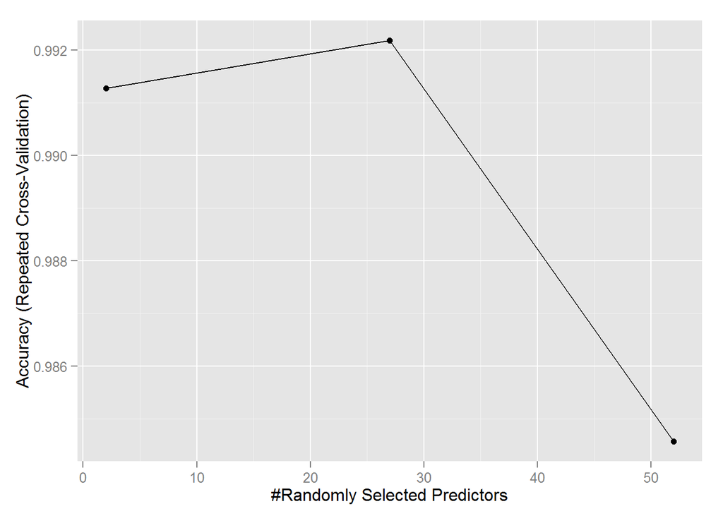

```r
ggplot(fit)
```

# Testing and error

We will now use the testing data set to validate our model. First, we’ll use the model to predict the *classe* outcome and then we’ll compare those predictions with the actual values stored in the data set. The confusion matrix will tell us the accuracy of the evaluation, among others.

```r
test <- predict(fit, testing)
confMat <- confusionMatrix(test, testing$classe)
# accuracy is printed with the confusion matrix
confMat
```

```
## Confusion Matrix and Statistics
##
##           Reference
## Prediction    A    B    C    D    E
##          A 1638    7    0    0    0
##          B    1 1102    3    0    0
##          C    1    6  998   11    0
##          D    0    0    4  932    1
##          E    1    0    0    1 1057
##
## Overall Statistics
##
##                Accuracy : 0.9938
##                  95% CI : (0.9914, 0.9956)
##     No Information Rate : 0.2847
##     P-Value [Acc > NIR] : < 2.2e-16
##
##                   Kappa : 0.9921
##  Mcnemar's Test P-Value : NA
##
## Statistics by Class:
##
##                      Class: A Class: B Class: C Class: D Class: E
## Sensitivity            0.9982   0.9883   0.9930   0.9873   0.9991
## Specificity            0.9983   0.9991   0.9962   0.9990   0.9996
## Pos Pred Value         0.9957   0.9964   0.9823   0.9947   0.9981
## Neg Pred Value         0.9993   0.9972   0.9985   0.9975   0.9998
## Prevalence             0.2847   0.1935   0.1744   0.1638   0.1836
## Detection Rate         0.2842   0.1912   0.1732   0.1617   0.1834
## Detection Prevalence   0.2854   0.1919   0.1763   0.1626   0.1838
## Balanced Accuracy      0.9982   0.9937   0.9946   0.9931   0.9993
```

This gives us an accuracy of 99.38%. We have enough accuracy for this project, so we don’t need to explore other algorithms or use additional improvement techniques. We can now validate our model on the additional 20 samples provided in the *pml-testing.csv* file.

```r
pml_write_files = function(x){
    n = length(x)
    for(i in 1:n){
        filename = paste0("problem_id_",i,".txt")
        write.table(x[i],file=filename,quote=FALSE,row.names=FALSE,col.names=FALSE)
    }
}

validationData <- read.csv("pml-testing.csv", na.strings=c('', 'NA', '#DIV/0!', ' '), stringsAsFactors=FALSE)
result <- predict(fit, validationData)
pml_write_files(result)
result
```

```
##  [1] B A B A A E D B A A B C B A E E A B B B
## Levels: A B C D E
```

# References

[1] Velloso, E.; Bulling, A.; Gellersen, H.; Ugulino, W.; Fuks, H. *Qualitative Activity Recognition of Weight Lifting Exercises*. Proceedings of 4th International Conference in Cooperation with SIGCHI (Augmented Human ’13) . Stuttgart, Germany: ACM SIGCHI, 2013.

[2] http://groupware.les.inf.puc-rio.br/har#ixzz3Uzn2UKqS

[3] https://class.coursera.org/predmachlearn-012